# Cyclistic Bike Sharing Analysis

Autor : Burak Demir

Date : 2022-08-01

## Case Study: How Does a Bike-Share Navigate Speedy Success ?

### About Company

In 2016, Cyclistic launched a successful bike-share offering. Since then, the program has grown to a fleet of 5,824 bicycles that are geotracked and locked into a network of 692 stations across Chicago. The bikes can be unlocked from one station and returned to any other station in the system anytime.

This case study will follow 6 steps of data analysis

**1)** **ASK**

Our main focus will be these questions.

- **How do annual members and casual riders use Cyclistic bikes differently?**
- **Why would a casual rider to buy our annual membership?**

Key Stakeholders

- Lily Moreno: The director of marketing and your manager. Moreno is responsible for the development of campaigns and initiatives to promote the bike-share program. These may include email, social media, and other channels.
- Cyclistic marketing analytics team: A team of data analysts who are responsible for collecting, analyzing, and reporting data that helps guide Cyclistic marketing strategy.
- Cyclistic executive team: The notoriously detail-oriented executive team will decide whether to approve the recommended marketing program

**2)** **PREPARE**

- We will use Cyclistic’s historical trip [data](https://divvy-tripdata.s3.amazonaws.com/index.html) to analyze and identify trends. The data has been made available by Motivate International Inc. under this [license](https://ride.divvybikes.com/data-license-agreement). This is public data that we can use to explore how different customer types are using Cyclistic bikes. But note that data-privacy issues prohibit us from using riders’ personally identifiable information. This means that we won’t be able to connect pass purchases to credit card numbers to determine if casual riders live in the Cyclistic service area or if they have purchased multiple single passes.
- The data used in this project includes data between the dates 01.2021 - 12.2021
- R will be used in this project because of the perform calculation easily on this big dataset

**3)** **PROCESS**

**3.1)** First of all we load necessary libraries

```r
# Loading necessary libraries
library(tidyverse)
library(lubridate)
library(here)
```

**3.2)** Loading our csv files the data between (01.2021 - 12.2021)

```r
df1 <- read_csv(here("Csv Files", "202101-divvy-tripdata.csv"))
df2 <- read_csv(here("Csv Files", "202102-divvy-tripdata.csv"))
df3 <- read_csv(here("Csv Files", "202103-divvy-tripdata.csv"))
df4 <- read_csv(here("Csv Files", "202104-divvy-tripdata.csv"))
df5 <- read_csv(here("Csv Files", "202105-divvy-tripdata.csv"))
df6 <- read_csv(here("Csv Files", "202106-divvy-tripdata.csv"))
df7 <- read_csv(here("Csv Files", "202107-divvy-tripdata.csv"))
df8 <- read_csv(here("Csv Files", "202108-divvy-tripdata.csv"))
df9 <- read_csv(here("Csv Files", "202109-divvy-tripdata.csv"))
df10 <- read_csv(here("Csv Files", "202110-divvy-tripdata.csv"))
df11 <- read_csv(here("Csv Files", "202111-divvy-tripdata.csv"))
df12 <- read_csv(here("Csv Files", "202112-divvy-tripdata.csv"))
```

**3.3)** Combining all data frames into one data frame

```r
tripdata_2021 <- rbind(df1,df2,df3,df4,df5,df6,df7,df8,df9,df10,df11,df12)
```

**3.4)** Writing new csv files for our aggregated data frame

```r
write.csv(tripdata_2021, file = "tripdata_2021.csv", row.names = FALSE)
```

**3.5)** Removing all csv files to make our environment clear

```r
rm(df1,df2,df3,df4,df5,df6,df7,df8,df9,df10,df11,df12)
```

**3.6)** Exploring combined data frame

```r
View(tripdata_2021)
```

**3.7)** Removing unnecessary columns from our data frame

```r
tripdata_2021 <- subset(tripdata_2021, select = -c(start_lat, start_lng, end_lat, end_lng, start_station_id, end_station_id))
```

**3.8)** Giving member_casual column a meaningful name

```r
tripdata_2021 <- rename(tripdata_2021, customer_type = member_casual)
```

**3.9)** Exploring new cleaned data frame

```r
colnames(tripdata_2021) # Gives us name of columns in our data frame
```

```
## [1] "ride_id"            "rideable_type"      "started_at"
## [4] "ended_at"           "start_station_name" "end_station_name"
## [7] "customer_type"
```

```r
nrow(tripdata_2021) # Gives us number of rows in our data frame
```

```
## [1] 5595063
```

```r
dim_desc(tripdata_2021) # Gives us dimensions of our data frame
```

```
## [1] "[5,595,063 x 7]"
```

```r
glimpse(tripdata_2021) # Gives us general information about our data frame
```

```
## Rows: 5,595,063
## Columns: 7
## $ ride_id            <chr> "E19E6F1B8D4C42ED", "DC88F20C2C55F27F", "EC45C94683~
## $ rideable_type      <chr> "electric_bike", "electric_bike", "electric_bike", ~
## $ started_at         <dttm> 2021-01-23 16:14:19, 2021-01-27 18:43:08, 2021-01-~
## $ ended_at           <dttm> 2021-01-23 16:24:44, 2021-01-27 18:47:12, 2021-01-~
## $ start_station_name <chr> "California Ave & Cortez St", "California Ave & Cor~
## $ end_station_name   <chr> NA, NA, NA, NA, NA, NA, NA, NA, NA, "Wood St & Augu~
## $ customer_type      <chr> "member", "member", "member", "member", "casual", "~
```

```r
str(tripdata_2021) # Gives us structure information about our data frame
```

```
## tibble [5,595,063 x 7] (S3: tbl_df/tbl/data.frame)
##  $ ride_id           : chr [1:5595063] "E19E6F1B8D4C42ED" "DC88F20C2C55F27F" "EC45C94683FE3F27" "4FA453A75AE377DB" ...
##  $ rideable_type     : chr [1:5595063] "electric_bike" "electric_bike" "electric_bike" "electric_bike" ...
##  $ started_at        : POSIXct[1:5595063], format: "2021-01-23 16:14:19" "2021-01-27 18:43:08" ...
##  $ ended_at          : POSIXct[1:5595063], format: "2021-01-23 16:24:44" "2021-01-27 18:47:12" ...
##  $ start_station_name: chr [1:5595063] "California Ave & Cortez St" "California Ave & Cortez St" "California Ave & Cortez St" "California Ave & Cortez St" ...
##  $ end_station_name  : chr [1:5595063] NA NA NA NA ...
##  $ customer_type     : chr [1:5595063] "member" "member" "member" "member" ...
```

```r
summary(tripdata_2021) # Gives us quick summary of our data frame inc min max median
```

```
##    ride_id          rideable_type        started_at
##  Length:5595063     Length:5595063     Min.   :2021-01-01 00:02:05
##  Class :character   Class :character   1st Qu.:2021-06-06 23:52:40
##  Mode  :character   Mode  :character   Median :2021-08-01 01:52:11
##                                        Mean   :2021-07-29 07:41:02
##                                        3rd Qu.:2021-09-24 16:36:16
##                                        Max.   :2021-12-31 23:59:48
##     ended_at                   start_station_name end_station_name
##  Min.   :2021-01-01 00:08:39   Length:5595063     Length:5595063
##  1st Qu.:2021-06-07 00:44:21   Class :character   Class :character
##  Median :2021-08-01 02:21:55   Mode  :character   Mode  :character
##  Mean   :2021-07-29 08:02:58
##  3rd Qu.:2021-09-24 16:54:05
##  Max.   :2022-01-03 17:32:18
##  customer_type
##  Length:5595063
##  Class :character
##  Mode  :character
##
##
##
```

**3.10)** We can add new columns that shows us Day, Month, Year for each ride. This will allow us to aggregate ride information in different time categories

```r
tripdata_2021$date <- as.Date(tripdata_2021$started_at)
tripdata_2021$day <- format(as.Date(tripdata_2021$date), "%d")
tripdata_2021$month <- format(as.Date(tripdata_2021$date), "%m")
tripdata_2021$year <- format(as.Date(tripdata_2021$date), "%Y")
tripdata_2021$day_of_week <- format(as.Date(tripdata_2021$date), "%A")
tripdata_2021$time <- format(tripdata_2021$started_at, format= "%H:%M")
tripdata_2021$time <- as.POSIXct(tripdata_2021$time, format= "%H:%M")
```

**3.11)** Adding ride length calculation to our data frame shows each ride length

```r
tripdata_2021$ride_length <- (as.double(difftime(tripdata_2021$ended_at, tripdata_2021$started_at)))/60
```

**3.12)** Checking new data frame for each data type

```r
str(tripdata_2021)
```

```
## tibble [5,595,063 x 14] (S3: tbl_df/tbl/data.frame)
##  $ ride_id           : chr [1:5595063] "E19E6F1B8D4C42ED" "DC88F20C2C55F27F" "EC45C94683FE3F27" "4FA453A75AE377DB" ...
##  $ rideable_type     : chr [1:5595063] "electric_bike" "electric_bike" "electric_bike" "electric_bike" ...
##  $ started_at        : POSIXct[1:5595063], format: "2021-01-23 16:14:19" "2021-01-27 18:43:08" ...
##  $ ended_at          : POSIXct[1:5595063], format: "2021-01-23 16:24:44" "2021-01-27 18:47:12" ...
##  $ start_station_name: chr [1:5595063] "California Ave & Cortez St" "California Ave & Cortez St" "California Ave & Cortez St" "California Ave & Cortez St" ...
##  $ end_station_name  : chr [1:5595063] NA NA NA NA ...
##  $ customer_type     : chr [1:5595063] "member" "member" "member" "member" ...
##  $ date              : Date[1:5595063], format: "2021-01-23" "2021-01-27" ...
##  $ day               : chr [1:5595063] "23" "27" "21" "07" ...
##  $ month             : chr [1:5595063] "01" "01" "01" "01" ...
##  $ year              : chr [1:5595063] "2021" "2021" "2021" "2021" ...
##  $ day_of_week       : chr [1:5595063] "Saturday" "Wednesday" "Thursday" "Thursday" ...
##  $ time              : POSIXct[1:5595063], format: "2022-08-10 16:14:00" "2022-08-10 18:43:00" ...
##  $ ride_length       : num [1:5595063] 10.417 4.067 1.333 11.7 0.717 ...
```

```r
tripdata_2021 <- tripdata_2021[!(tripdata_2021$start_station_name == "HQ QR" | tripdata_2021$ride_length<0),]
```

**3.14)** Quick Summary for new dataset

```r
summary(tripdata_2021$ride_length)
```

```
##    Min. 1st Qu.  Median    Mean 3rd Qu.    Max.    NA's
##     0.0     6.9    12.2    22.8    22.1 55944.2  690789
```

**3.15)** There are lots of NA entries in ride_length column, Let’s remove them

```r
tripdata_2021 <- na.omit(tripdata_2021)

summary(tripdata_2021$ride_length)
```

```
##     Min.  1st Qu.   Median     Mean  3rd Qu.     Max.
##     0.00     6.95    12.20    21.81    22.12 55944.15
```

**3.16)** Another save point for the cleaned data

```r
write.csv(tripdata_2021, file = "tripdata_2021_cleaned.csv", row.names = FALSE)
```

**4)** **ANALYZE**

Now our data has cleaned and ready to work on it.

**4.1)** It is time to compare customer types in ride_length

```r
aggregate(tripdata_2021$ride_length ~ tripdata_2021$customer_type, FUN = mean)
```

```
##   tripdata_2021$customer_type tripdata_2021$ride_length
## 1                      casual                  32.50963
## 2                      member                  13.18375
```

```r
aggregate(tripdata_2021$ride_length ~ tripdata_2021$customer_type, FUN = median)
```

```
##   tripdata_2021$customer_type tripdata_2021$ride_length
## 1                      casual                 16.650000
## 2                      member                  9.716667
```

```r
aggregate(tripdata_2021$ride_length ~ tripdata_2021$customer_type, FUN = max)
```

```
##   tripdata_2021$customer_type tripdata_2021$ride_length
## 1                      casual                 55944.150
## 2                      member                  1495.633
```

```r
aggregate(tripdata_2021$ride_length ~ tripdata_2021$customer_type, FUN = min)
```

```
##   tripdata_2021$customer_type tripdata_2021$ride_length
## 1                      casual                         0
## 2                      member                         0
```

**4.2)** Let’s find out the each day of the week

```r
aggregate(tripdata_2021$ride_length ~ tripdata_2021$customer_type + tripdata_2021$day_of_week, FUN = mean)
```

```
##    tripdata_2021$customer_type tripdata_2021$day_of_week
## 1                       casual                    Friday
## 2                       member                    Friday
## 3                       casual                    Monday
## 4                       member                    Monday
## 5                       casual                  Saturday
## 6                       member                  Saturday
## 7                       casual                    Sunday
## 8                       member                    Sunday
## 9                       casual                  Thursday
## 10                      member                  Thursday
## 11                      casual                   Tuesday
## 12                      member                   Tuesday
## 13                      casual                 Wednesday
## 14                      member                 Wednesday
##    tripdata_2021$ride_length
## 1                   30.91843
## 2                   12.79233
## 3                   32.63681
## 4                   12.72502
## 5                   34.87188
## 6                   14.81946
## 7                   37.60286
## 8                   15.19426
## 9                   28.01063
## 10                  12.35363
## 11                  28.80295
## 12                  12.38767
## 13                  28.26925
## 14                  12.45793
```

**4.3)** Make days of the week in order

```r
tripdata_2021$day_of_week <- ordered(tripdata_2021$day_of_week, levels=c("Monday", "Tuesday", "Wednesday", "Thursday", "Friday", "Saturday", "Sunday"))

aggregate(tripdata_2021$ride_length ~ tripdata_2021$customer_type + tripdata_2021$day_of_week, FUN = mean)
```

```
##    tripdata_2021$customer_type tripdata_2021$day_of_week
## 1                       casual                    Monday
## 2                       member                    Monday
## 3                       casual                   Tuesday
## 4                       member                   Tuesday
## 5                       casual                 Wednesday
## 6                       member                 Wednesday
## 7                       casual                  Thursday
## 8                       member                  Thursday
## 9                       casual                    Friday
## 10                      member                    Friday
## 11                      casual                  Saturday
## 12                      member                  Saturday
## 13                      casual                    Sunday
## 14                      member                    Sunday
##    tripdata_2021$ride_length
## 1                   32.63681
## 2                   12.72502
## 3                   28.80295
## 4                   12.38767
## 5                   28.26925
## 6                   12.45793
## 7                   28.01063
## 8                   12.35363
## 9                   30.91843
## 10                  12.79233
## 11                  34.87188
## 12                  14.81946
## 13                  37.60286
## 14                  15.19426
```

**4.4)** Analyzing the data by customer type

```r
tripdata_2021 %>%
  mutate(day_of_week = wday(started_at, label = TRUE)) %>%
  group_by(customer_type, day_of_week) %>%
  summarise(number_of_rides = n()
            ,average_duration = mean(ride_length)) %>%
  arrange(customer_type, day_of_week)
```

```
## # A tibble: 14 x 4
## # Groups:   customer_type [2]
##    customer_type day_of_week number_of_rides average_duration
##    <chr>         <ord>                 <int>            <dbl>
##  1 casual        Sun                  403762             37.6
##  2 casual        Mon                  228934             32.6
##  3 casual        Tue                  214935             28.8
##  4 casual        Wed                  218132             28.3
##  5 casual        Thu                  224207             28.0
##  6 casual        Fri                  290040             30.9
##  7 casual        Sat                  468325             34.9
##  8 member        Sun                  311220             15.2
##  9 member        Mon                  346481             12.7
## 10 member        Tue                  388131             12.4
## 11 member        Wed                  397688             12.5
## 12 member        Thu                  373471             12.4
## 13 member        Fri                  365782             12.8
## 14 member        Sat                  357078             14.8
```

**4.5)** Data Visualization

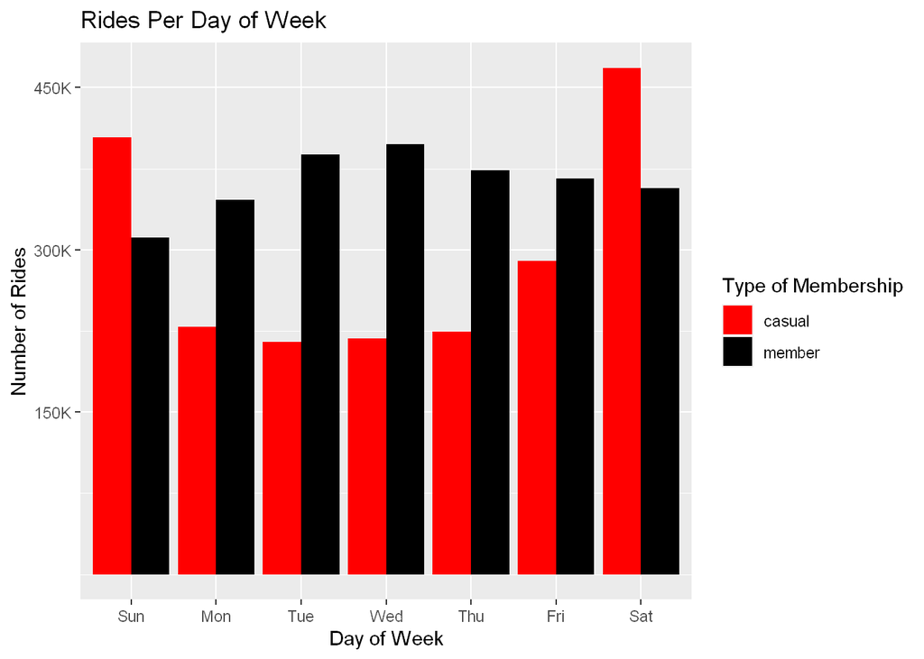

```r
tripdata_2021 %>%
  mutate(day_of_week = wday(started_at, label = TRUE)) %>%
  group_by(customer_type, day_of_week) %>%
  summarise(number_of_rides = n()
            ,average_duration = mean(ride_length)) %>%
  arrange(customer_type, day_of_week) %>%
  ggplot(aes(x = day_of_week, y = number_of_rides, fill = customer_type)) + geom_col(position = "dodge")+
  labs(x = "Day of Week", y = "Number of Rides", title = "Rides Per Day of Week", fill = "Type of Membership")+
  scale_y_continuous(breaks = c(150000, 300000, 450000), labels = c("150K", "300K", "450K"))+
  scale_fill_manual(values = c("casual"="Red", "member"="Black"))
```

- This plot shows us casual members use bikes on weekends, and usage in weekdays dramatically lower. On the other hand members use bikes regularly in whole week for their commute, on weekends like leisure usage drops slightly

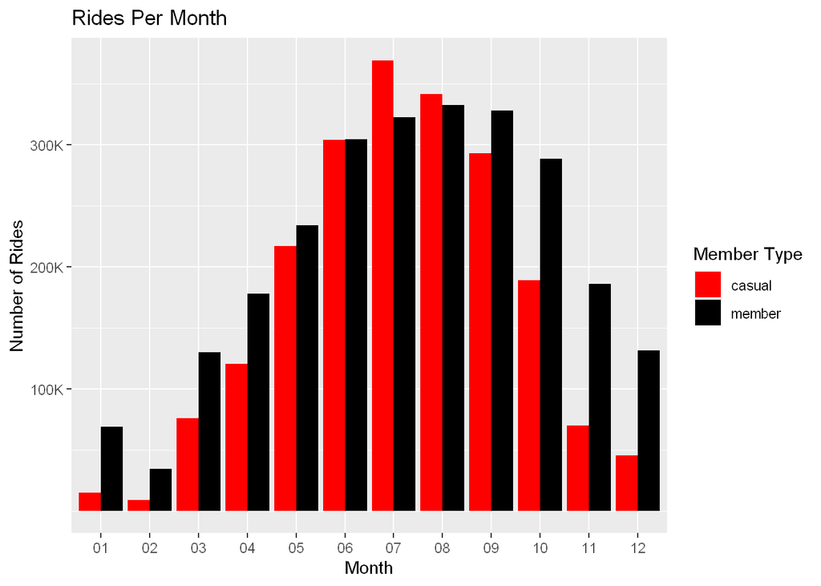

```r
tripdata_2021 %>%
  group_by(customer_type, month) %>%
  summarise(number_of_rides = n(), `average_duration(mins)` = mean(ride_length)) %>%
  arrange(customer_type) %>%
  ggplot(aes(x = month, y = number_of_rides, fill = customer_type)) + geom_col(position = "dodge") +
  labs(x = "Month", y = "Number of Rides", title = "Rides Per Month", fill = "Member Type")+
  scale_y_continuous(breaks = c(100000, 200000, 300000, 400000), labels = c("100K", "200K", "300K", "400K"))+
  scale_fill_manual(values = c("casual"="Red", "member"="Black"))
```

- This plot shows us Casual riders are more active in summer seasons and their activity sharply decrease in October
- Member riders shows same trend like Casual riders but their activity decrease slightly. Especially members are more active in Autumn

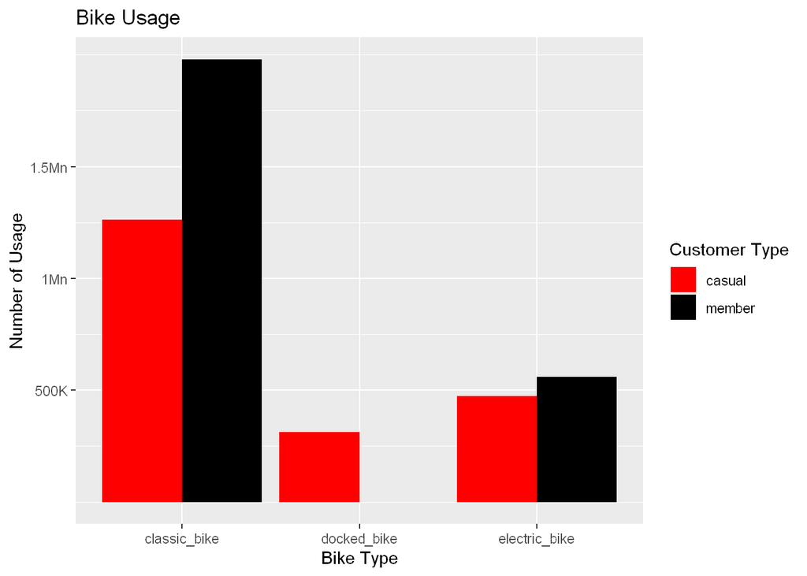

```r
tripdata_2021 %>%
  group_by(customer_type, rideable_type) %>%
  summarise(number_of_usage = n()) %>%
  ggplot(aes(x = rideable_type, y = number_of_usage, fill = customer_type)) +
  geom_col(position = "dodge") +
  labs(x = "Bike Type", y = "Number of Usage", title = "Bike Usage", fill = "Customer Type") +
  scale_y_continuous(breaks = c(500000, 1000000, 1500000), labels = c("500K", "1Mn", "1.5Mn"))+
  scale_fill_manual(values = c("casual"="Red", "member"="Black"))
```

- Classic bike and Electric bike are the most popular bike types using by the customers. Members are the highest user of classic bikes and the electric bikes
- On the other hand docked bikes are only used by the casual members

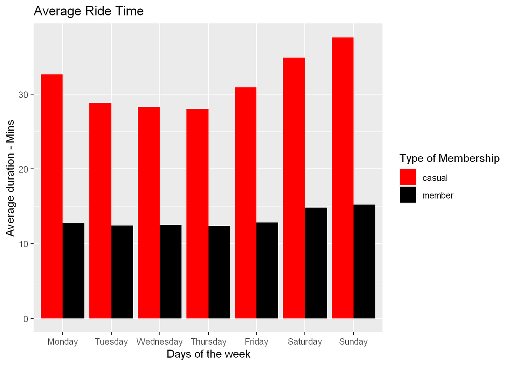

```r
tripdata_2021 %>%
  group_by(customer_type, day_of_week) %>%
  summarise(number_of_rides = n()
            ,average_duration = mean(ride_length)) %>%
  arrange(customer_type, day_of_week)  %>%
  ggplot(aes(x = day_of_week, y = average_duration, fill = customer_type)) +
  geom_col(position = "dodge") + labs(x='Days of the week', y='Average duration - Mins', title='Average Ride Time', fill='Type of Membership')+
  scale_fill_manual(values = c("casual"="Red", "member"="Black"))
```

- In general the average time for each ride for Casual riders are more than the member riders.

**5)** **SHARE**

Our findings from visualizations

**5.1)** Usage Per Day of the Week  
Casual riders use service more often in weekends.

**5.2)** Usage Per Month of the Year  
General service usage sharply increases from March to July for the both customer type. In summer time casual rider category makes peak in July.

**5.3)** Bike Type Usage  
Classic bike and the electric bike are the most popular bikes for each customer type. The docked bike type is using by the casual members only.

**5.4)** Average Time of Usage Casual riders use bike extremely more than member riders whole through the week.

**6)** **ACT**

**Recommendations**

To convert casual riders into member riders,

- The information we have obtained from the analysis and visuals, if the company organizes annual membership campaigns for casual riders on weekends, it may increase the number of annual memberships.
- In the same way, looking at the number of usage of bicycles on a monthly basis, there has been a significant increase in both user types since the beginning of spring, annual membership benefits can be delivered to casual riders with a number of marketing campaigns, and an email or application notification can be sent as an example containing the advantages of membership purchase.
- The docked bike is used almost exclusively by casual riders, so a strategy can be developed to reach users who use this type of bike and convert their membership type to annual membership.
- Average usage time shows that casual riders use bikes longer than riders with membership. Generally casual riders use the bikes for 25 minutes or longer on average, a number of strategies can be developed in this section and the number of memberships can be increased.

**Conclusion**

Through this analysis, we have successfully identified different patterns and trends among casual riders and members of Cyclistic bike-share company. This could help in formulating new marketing strategies to attract casual users to buy membership.

Working on this project is personally rewarding and helped me apply the things I learnt in the course on the real world problem.

Thank you.